**산업체 재직자 대상 인공지능 핵심 기초 교육**  
**XAI: exPlainable Artificial Intelligence**

By Prof. Seungchul Lee  
http://iai.postech.ac.kr/  
Industrial AI Lab at POSTECH

Table of Contents

# 1. Black Box AI

- Black box AI: AI produces insights based on a data set, but the end-user doesn’t know how
  - Many machine learning and deep learning models share ‘black box’ problem
  - AI does not provide reasons behind the decision or prediction it makes
  - The reliability of AI models may be questioned

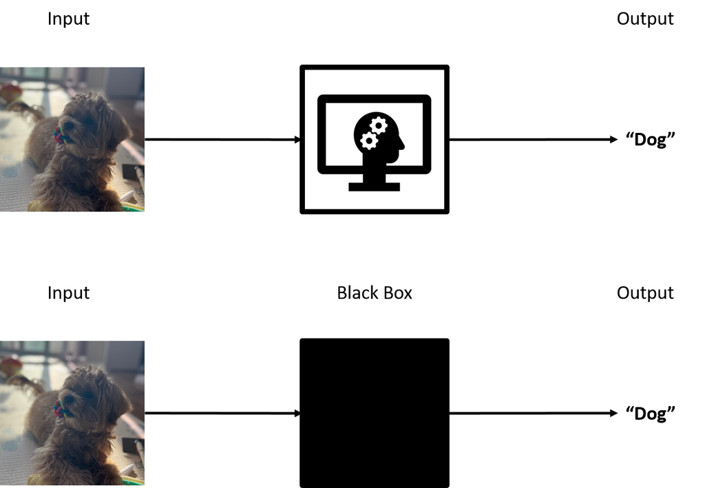

- XAI which humans can understand the decisions or predictions made by the AI

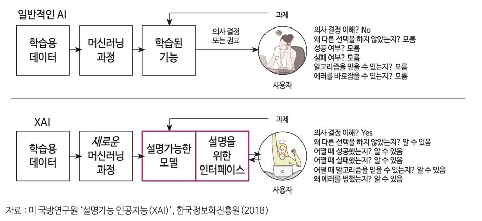

**Why XAI?**

- XAI can be used to increase the interpretability of AI by enabling description of the expected outcome and potential bias of the model
- Depending on the AI performance, XAI results can be used in various ways:
  - AI performance < Human performance
    - XAI suggests improvement directions for AI models
  - AI performance ≈ Human performance
    - XAI identifies the principles behind AI model learning
  - AI performance > Human performance
    - XAI enables acquiring new knowledge from AI

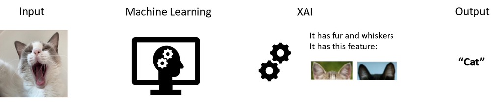

**Model-Specific XAI**

- Model-Specific XAI: only applicable to specific algorithms that provides explanations by using the intrinsic structure of the model
  - Examples: Class Activation Mapping (CAM) & Gradient-CAM for Convolution Neural Network (CNN) models

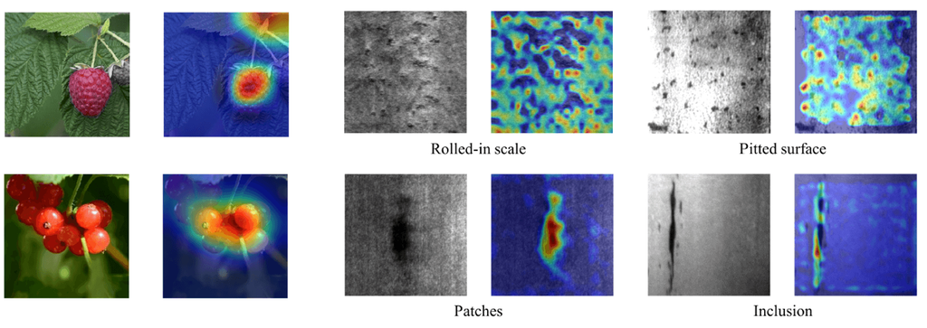

**Model-Agnostic XAI**

- Model Agnostic XAI: applicable to any machine learning algorithms and work on the black box model
  - Obtain explanations by perturbing and mutating the input data and obtaining sensitivity of the performance of theses mutations with respect to the original data performance
  - Examples:
    - SHapley Additive exPlanations (SHAP)
    - Local Interpretable Model-agnostic Explanations (LIME)

[figure not shown]

# 2. SHapley Additive exPlanations (SHAP)

- SHAP: a game theoretic approach to explain the output of any machine learning model
  - Compute feature importance on each predicted value using Shapley value
  - According to the SHAP value, the contribution of each feature can be expressed as the degree of change in the overall performance when the contribution of that feature is excluded
  - Unlike general permutation method, SHAP calculates the model influence by considering the dependencies between features

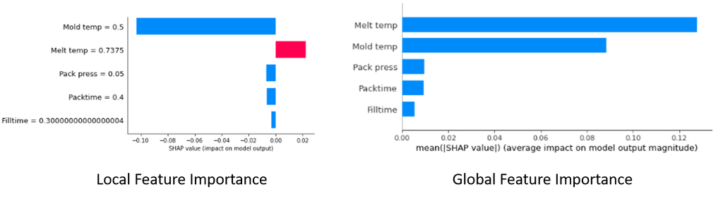

**Mount drive**

```python
from google.colab import drive
drive.mount('/content/drive')
```

**Import Libraries**

```python
from sklearn.model_selection import train_test_split
import matplotlib.pyplot as plt
import pandas as pd
import numpy as np
import tensorflow as tf
```

**Define Input Data**

# 3. Build and Predict Machine Learning and Deep Learning Models

## 3.1. Data Description

- Injection molding dataset consisting of 36 mold shapes
- This dataset consists of 5 process features (control parameters), 32 mold shape features, and the weight of the molded part (ground truth).

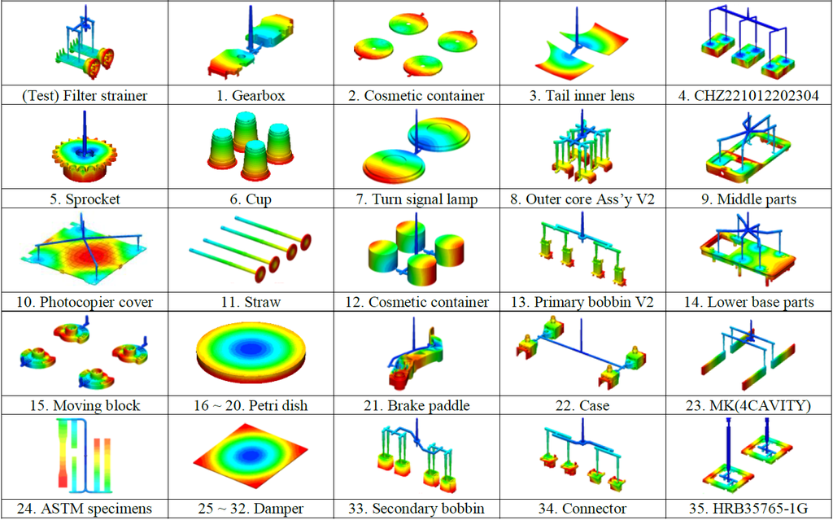

```python
dataset = pd.read_excel('/content/drive/MyDrive/linc/data_files/train_dataset.xlsx',
                        index_col = 0,
                        engine = 'openpyxl')
```

```python
dataset
```

| MoldNumber | Fill time (sec) | Melt temperature (℃) | Mold temperature (℃) | Packing pressure (MPa) | Packing time (sec) | OverallProjectionAreaZX | MinGateHydraulicDiameter | CavityVolume | StdFlowLength | RunnerSurfaceArea | ... | NumberOfCavities | AvgPartThickness | AvgGateHydraulicDiameter | Overall_Compactness | Cavity_Compactness | Runner_Compactness | CavitySurfaceToVolume | RunnerSurfaceToVolume | OverallSurfaceToVolume | Weight (g) |
| --- | --- | --- | --- | --- | --- | --- | --- | --- | --- | --- | --- | --- | --- | --- | --- | --- | --- | --- | --- | --- | --- |
| 1 | 0.7 | 232 | 31 | 43 | 2.7 | 19.686 | 0.55 | 14.804 | 0.601 | 16.797 | ... | 2 | 1.253 | 0.813 | 1.398630 | 1.323422 | 2.400429 | 15.112335 | 8.331845 | 14.299703 | 13.7819 |
| 1 | 0.5 | 220 | 40 | 51 | 1.3 | 19.686 | 0.55 | 14.804 | 0.601 | 16.797 | ... | 2 | 1.253 | 0.813 | 1.398630 | 1.323422 | 2.400429 | 15.112335 | 8.331845 | 14.299703 | 13.1317 |
| 1 | 1.4 | 221 | 51 | 46 | 1.3 | 19.686 | 0.55 | 14.804 | 0.601 | 16.797 | ... | 2 | 1.253 | 0.813 | 1.398630 | 1.323422 | 2.400429 | 15.112335 | 8.331845 | 14.299703 | 13.3700 |
| 1 | 0.8 | 234 | 34 | 61 | 2.0 | 19.686 | 0.55 | 14.804 | 0.601 | 16.797 | ... | 2 | 1.253 | 0.813 | 1.398630 | 1.323422 | 2.400429 | 15.112335 | 8.331845 | 14.299703 | 13.5909 |
| 1 | 1.1 | 239 | 44 | 37 | 2.6 | 19.686 | 0.55 | 14.804 | 0.601 | 16.797 | ... | 2 | 1.253 | 0.813 | 1.398630 | 1.323422 | 2.400429 | 15.112335 | 8.331845 | 14.299703 | 13.7390 |
| ... | ... | ... | ... | ... | ... | ... | ... | ... | ... | ... | ... | ... | ... | ... | ... | ... | ... | ... | ... | ... | ... |
| 35 | 1.5 | 225 | 30 | 70 | 2.0 | 77.579 | 0.98 | 14.441 | 0.259 | 39.768 | ... | 2 | 1.154 | 1.011 | 1.352616 | 1.188687 | 2.354154 | 16.825289 | 8.495621 | 14.786163 | 16.1268 |
| 35 | 1.5 | 225 | 30 | 70 | 3.0 | 77.579 | 0.98 | 14.441 | 0.259 | 39.768 | ... | 2 | 1.154 | 1.011 | 1.352616 | 1.188687 | 2.354154 | 16.825289 | 8.495621 | 14.786163 | 16.4245 |
| 35 | 1.5 | 240 | 45 | 30 | 1.0 | 77.579 | 0.98 | 14.441 | 0.259 | 39.768 | ... | 2 | 1.154 | 1.011 | 1.352616 | 1.188687 | 2.354154 | 16.825289 | 8.495621 | 14.786163 | 15.4136 |
| 35 | 1.5 | 240 | 45 | 30 | 2.0 | 77.579 | 0.98 | 14.441 | 0.259 | 39.768 | ... | 2 | 1.154 | 1.011 | 1.352616 | 1.188687 | 2.354154 | 16.825289 | 8.495621 | 14.786163 | 15.8083 |
| 35 | 1.5 | 240 | 45 | 30 | 3.0 | 77.579 | 0.98 | 14.441 | 0.259 | 39.768 | ... | 2 | 1.154 | 1.011 | 1.352616 | 1.188687 | 2.354154 | 16.825289 | 8.495621 | 14.786163 | 16.1344 |

3500 rows × 38 columns

```python
X = dataset.drop('Weight (g)', axis = 1)
y = dataset.loc[:, 'Weight (g)']
```

```python
X = (X - X.min()) / (X.max() - X.min())
```

- train/test split

```python
from sklearn.model_selection import train_test_split
train_x, test_x, train_y, test_y = train_test_split(X, y, test_size = 0.30, random_state = 42)
```

```python
print('train_x: {}, train_y: {}'.format(train_x.shape, train_y.shape))
print('test_x: {}, test_y: {}'.format(test_x.shape, test_y.shape))
```

```
train_x: (2450, 37), train_y: (2450,)
test_x: (1050, 37), test_y: (1050,)
```

# 4. XAI with Machine Learning

## 4.1. RandomForest Model

```python
from sklearn.ensemble import RandomForestRegressor
```

**Randomforest train**

```python
rf = RandomForestRegressor(random_state = 1)
rf.fit(train_x, train_y)
```

```
RandomForestRegressor(random_state=1)
```

**Prediction for testset**

```python
pred_y = rf.predict(test_x)
```

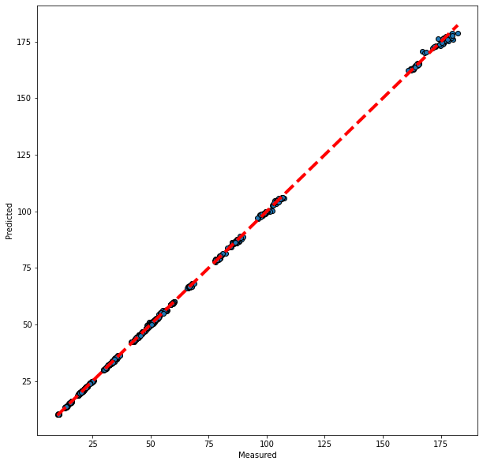

```python
fig, ax = plt.subplots(figsize=(10, 10))
ax.scatter(test_y, pred_y, edgecolors=(0, 0, 0))
ax.plot([y.min(), y.max()], [y.min(), y.max()], "r--", lw=4)
ax.set_xlabel("Measured")
ax.set_ylabel("Predicted")
plt.show()
```

## 4.2. SHAP

**SHAP Implementation**

```python
!pip install shap
```

```python
import shap

explainer = shap.TreeExplainer(rf)
shap_values = explainer.shap_values(test_x)
```

**Average of Absolute SHAP Values of Entire Test Data (Feature Importance)**

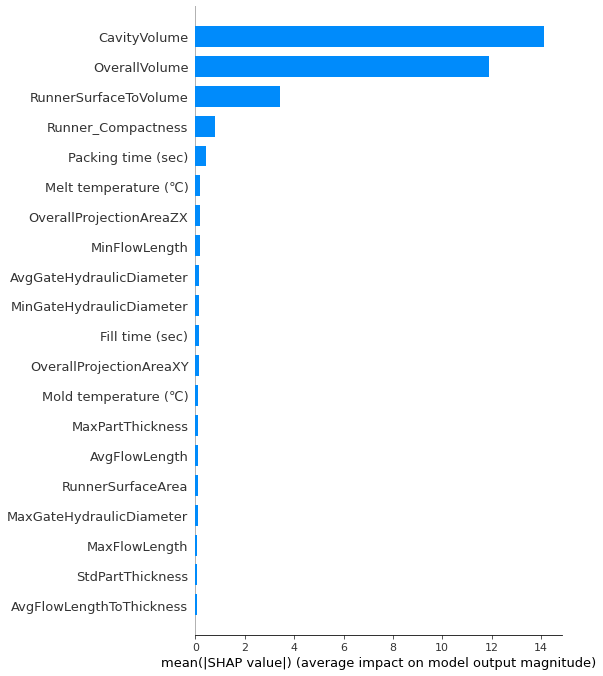

```python
shap.summary_plot(shap_values, test_x, plot_type = "bar")
```

# 5. XAI with Deep Learning

## 5.1. ANN Model

```python
tf.random.set_seed(42)

model = tf.keras.models.Sequential([
    tf.keras.layers.Input(shape = (train_x.shape[1],)),
    tf.keras.layers.Dense(units = 10, activation = 'relu'),
    tf.keras.layers.Dense(units = 10, activation = 'relu'),
    tf.keras.layers.Dense(units = 10, activation = 'relu'),
    tf.keras.layers.Dense(units = 10, activation = 'relu'),
    tf.keras.layers.Dense(units = 10, activation = 'relu'),
    tf.keras.layers.Dense(units = 1, activation = None)
])
```

**Model define and train**

```python
model.summary()
```

```
Model: "sequential"
_________________________________________________________________
 Layer (type)                Output Shape              Param #
=================================================================
 dense (Dense)               (None, 10)                380

 dense_1 (Dense)             (None, 10)                110

 dense_2 (Dense)             (None, 10)                110

 dense_3 (Dense)             (None, 10)                110

 dense_4 (Dense)             (None, 10)                110

 dense_5 (Dense)             (None, 1)                 11

=================================================================
Total params: 831
Trainable params: 831
Non-trainable params: 0
_________________________________________________________________
```

```python
model.compile(optimizer = tf.keras.optimizers.Adam(learning_rate = 0.001),
              loss = 'mse')
```

```python
loss = model.fit(train_x, train_y, epochs = 50)
```

**Prediction for testset**

```python
pred_y = model.predict(test_x)
```

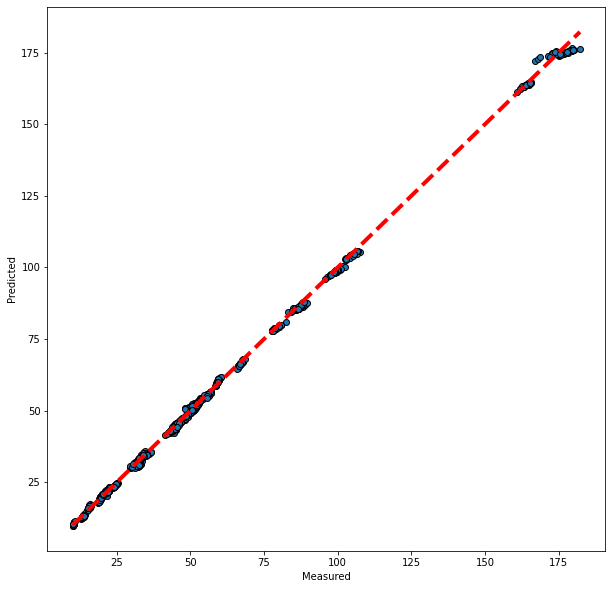

```python
fig, ax = plt.subplots(figsize=(10, 10))
ax.scatter(test_y, pred_y, edgecolors=(0, 0, 0))
ax.plot([test_y.min(), test_y.max()], [test_y.min(), test_y.max()], "r--", lw=4)
ax.set_xlabel("Measured")
ax.set_ylabel("Predicted")
plt.show()
```

## 5.2. SHAP

**SHAP Implementation**

```python
import shap

explainer_shap = shap.DeepExplainer(model = model,
                                    data = train_x.to_numpy())
shap_values = explainer_shap.shap_values(test_x.to_numpy())
```

[output not shown]

**Average of Absolute SHAP Values of Entire Test Data (Feature Importance)**

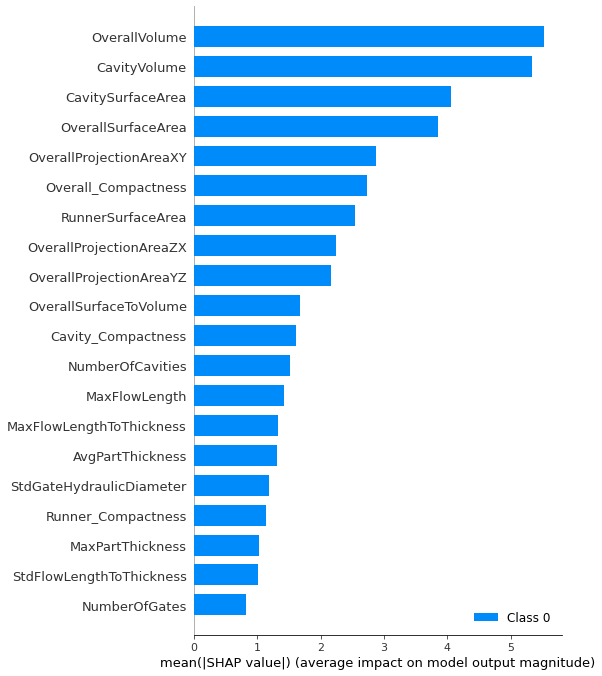

```python
shap.summary_plot(shap_values, test_x.to_numpy(),
                  feature_names = X.columns)
```

```python
%%javascript
$.getScript('https://kmahelona.github.io/ipython_notebook_goodies/ipython_notebook_toc.js')
```